### Grafico 2 : Ranking vs categoria.

Ordenamos los datos.

```r
joined_moviesFiltered <- joined_table[,c(13,11,26)]

comedy <- joined_moviesFiltered[grepl("Comedy",joined_movies$genres.x),]
action <- joined_moviesFiltered[grepl("Action",joined_movies$genres.x),]
sci_fi <- joined_moviesFiltered[grepl("Sci-Fi",joined_movies$genres.x),]
drama <- joined_moviesFiltered[grepl("Drama",joined_movies$genres.x),]
horror <- joined_moviesFiltered[grepl("Horror",joined_movies$genres.x),]
animation <- joined_moviesFiltered[grepl("Animation",joined_movies$genres.x),]
comedy$category <- "Comedy"
action$category <- "Action"
sci_fi$category <- "Sci-Fi"
drama$category <- "Drama"
horror$category <- "Horror"
animation$category <- "Animation"

by_category <- rbind(comedy,action,sci_fi,drama,horror,animation)[,c(1,3,4)]
```

Calculamos el grafico de distribuciones

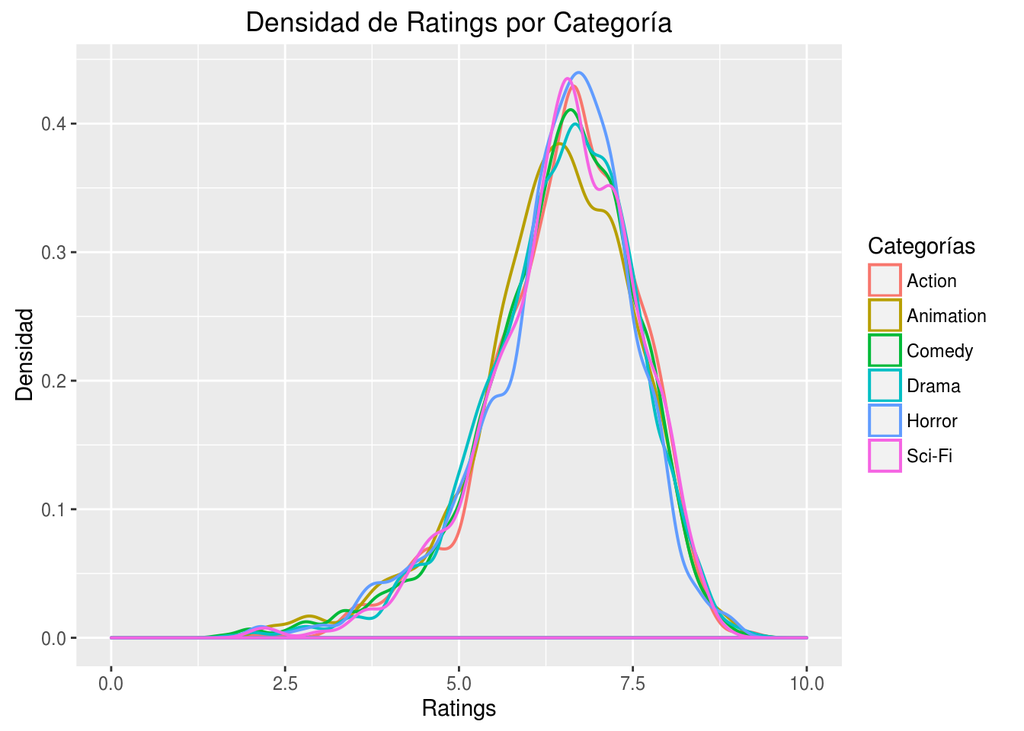

```r
ggplot(by_category,aes(x=by_category$imdb_score, colour = by_category$category), xlab = Rating) +
  geom_density(size = 0.7,adjust =0.7) +
  labs(title = "Densidad de Ratings por Categoría",x = "Ratings",y = "Densidad",colour = "Categorías") +
  xlim(0,10)
```

Obs -> el ranking que se evaluó es el de imbd

Calculamos el Histograma. Permite ver la diferencia de cantidades en los datos.

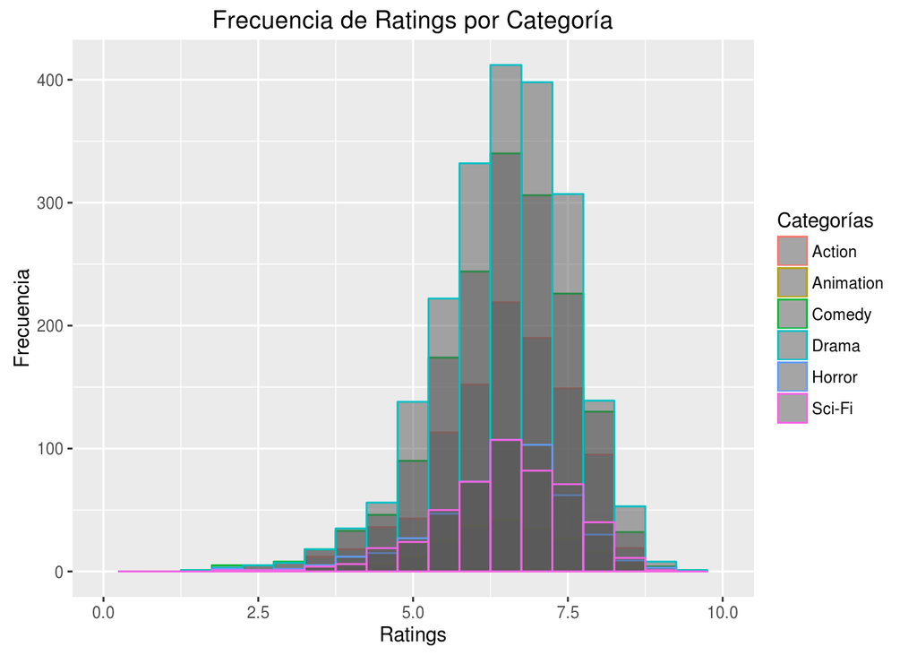

```r
ggplot(by_category,aes(x=by_category$imdb_score, colour = by_category$category)) +
    geom_histogram(binwidth=.5, alpha=.5, position="identity") +
    labs(title = "Frecuencia de Ratings por Categoría",x = "Ratings",y = "Frecuencia",colour = "Categorías")+
    xlim(0,10)
```

Vemos que podrían haber problemas para clasificar los datos en las categorías que tienen menos datos.

### Grafico 3 : Comparacion de notas de peliculas

Ordenamos los datos.

```r
dragon_ball <- ratings[ratings$movieId %in% 67867,c(2,3)]
avatar <- ratings[ratings$movieId %in% 72998,c(2,3)]
transformers2 <- ratings[ratings$movieId %in% 69526,c(2,3)]

by_numberofRatings <- rbind(dragon_ball,avatar,transformers2)
by_numberofRatings <- merge(by_numberofRatings,joined_movies)
```

Densidad

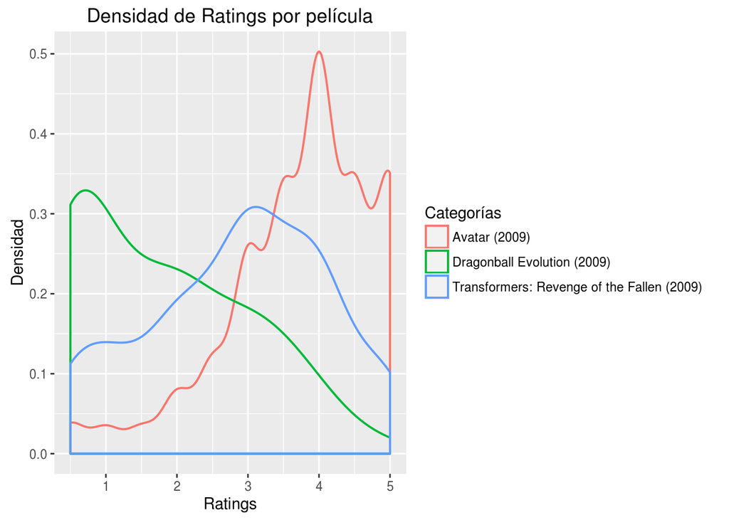

```r
ggplot(by_numberofRatings,aes(x=by_numberofRatings$rating, colour = by_numberofRatings$title)) +
  geom_density(size = 0.7,adjust = 1.5) +
  labs(title = "Densidad de Ratings por película",x = "Ratings",y = "Densidad",colour = "Categorías")
```

Histograma

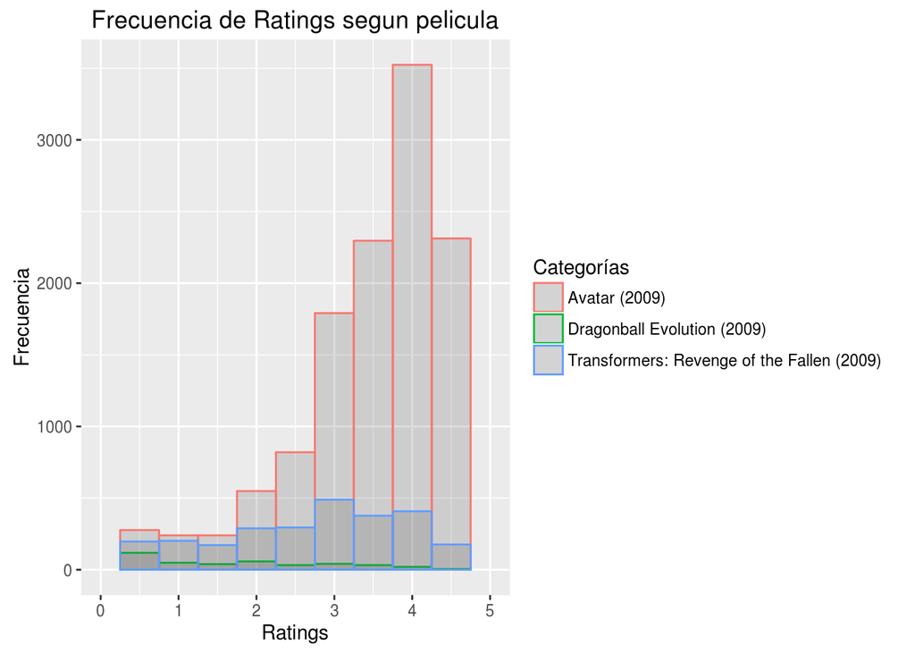

```r
ggplot(by_numberofRatings,aes(x=by_numberofRatings$rating, colour = by_numberofRatings$title)) +
  geom_histogram(binwidth=.5, alpha=.2, position="identity") +
  labs(title = "Frecuencia de Ratings segun pelicula",x = "Ratings",y = "Frecuencia",colour = "Categorías")+
  xlim(0,5)
```

puedo ver que las películas mas chantas aparentemente tienen menos votaciones que las películas con mas duración. Puede deberse a la popularidad de las mismas y al año de estreno (aunque no creo que esto ultimo se tan relevante)